# Script 7 - LDA scores, differencial abundances, and prevalence / relative abundances analyses

Microplastic exposure alters immune-related gene expression in Culex quinquefasciatus mosquitoes and larval microbiota diversity

Ahamed TCHATAKOURA, Marie BUYSSE, Marie-Laure SETIER RIO, Olivier ROUX, Claire LOISEAU, Amandine AVILES

# 0. Loading libraries

```r
library(phyloseq)
library(microbiome)
library(ggplot2)
library(ggrepel)
library(ggpubr)
library(dplyr)
library(kableExtra)
library(vegan)
library(tidyr)
library(metagMisc)
library(pairwiseAdonis)
library(DESeq2)
library(microbiomeMarker)
library(data.table)
library(FSA)
library(MuMIn)
library(sjPlot)
library(emmeans)
library(patchwork)
```

# 0. Load the datasets

```
metadata <- read.table("metadata.txt", sep="\t", dec = ",", header = TRUE, fill = TRUE, row.names = 1)
metadata$stage <- as.factor(metadata$stage)
metadata$stage <- factor(metadata$stage, levels = c("larvae", "female", "standard"))
metadata$sample_type <- as.factor(metadata$sample_type)
metadata$sample_type <- factor(metadata$sample_type, levels = c("larvae_whole", "female_whole", "female_midgut"))
metadata$treatment <- as.factor(metadata$treatment)
metadata$treatment <- factor(metadata$treatment, levels = c("control", "60", "200", "600"))
metadata$exposition <- as.factor(metadata$exposition)
metadata$exposition <- factor(metadata$exposition, levels = c("unexposed", "exposed"))
metadata$run <- as.factor(metadata$run)
metadata$stage_exp <- as.factor(metadata$stage_exp)
metadata$stage_exp <- factor(metadata$stage_exp, levels = c("UNEXP_larvae", "EXP_larvae", "UNEXP_female", "EXP_female", "UNEXP_femaleMID", "EXP_femaleMID"))

metadata_all <- metadata %>%
  filter(stage %in% c("larvae", "female"))

metadata_L <- metadata %>%
  filter(stage %in% c("larvae"))

metadata_F <- metadata %>%
  filter(stage %in% c("female"))
```

We create a dataset with only control individuals:

```
metadata_ctl <- metadata_all %>%
  filter(exposition %in% c("unexposed"))

load("rdata_ALL.RData")
rdata_ctl_1 <- subset_samples(rdata_all, exposition %in% c("unexposed"))
rdata_ctl <- prune_taxa(taxa_sums(rdata_ctl_1) > 0, rdata_ctl_1)
rdata_ctl_genus <- tax_glom(rdata_ctl, taxrank=rank_names(rdata_ctl)[6])
rdata_ctl_genus <- phyloseq_rm_na_tax(rdata_ctl_genus)
rdata_ctl_genus_rel <- microbiome::transform(rdata_ctl_genus, "compositional")
```

We create a dataset with only whole females:

```
metadata_FW <- metadata_F %>%
  filter(sample_type %in% c("female_whole"))

load("rdata_FEMALE.RData")
rdata_FW_1 <- subset_samples(rdata_F, sample_type %in% c("female_whole"))
rdata_FW <- prune_taxa(taxa_sums(rdata_FW_1) > 0, rdata_FW_1)
rdata_FW_genus <- tax_glom(rdata_FW, taxrank=rank_names(rdata_FW)[6])
rdata_FW_genus <- phyloseq_rm_na_tax(rdata_FW_genus)
rdata_FW_genus_rel <- microbiome::transform(rdata_FW_genus, "compositional")
```

We create a dataset with only midgut females:

```
metadata_FM <- metadata_F %>%
  filter(sample_type %in% c("female_midgut"))

load("rdata_FEMALE.RData")
rdata_FM_1 <- subset_samples(rdata_F, sample_type %in% c("female_midgut"))
rdata_FM <- prune_taxa(taxa_sums(rdata_FM_1) > 0, rdata_FM_1)
rdata_FM_genus <- tax_glom(rdata_FM, taxrank=rank_names(rdata_FM)[6])
rdata_FM_genus <- phyloseq_rm_na_tax(rdata_FM_genus)
rdata_FM_genus_rel <- microbiome::transform(rdata_FM_genus, "compositional")
```

# 1. Specific changes in larvae dataset

## 1.1. LDA scores according to exposure

```
load("rdata_LARVES_genus.RData")
```

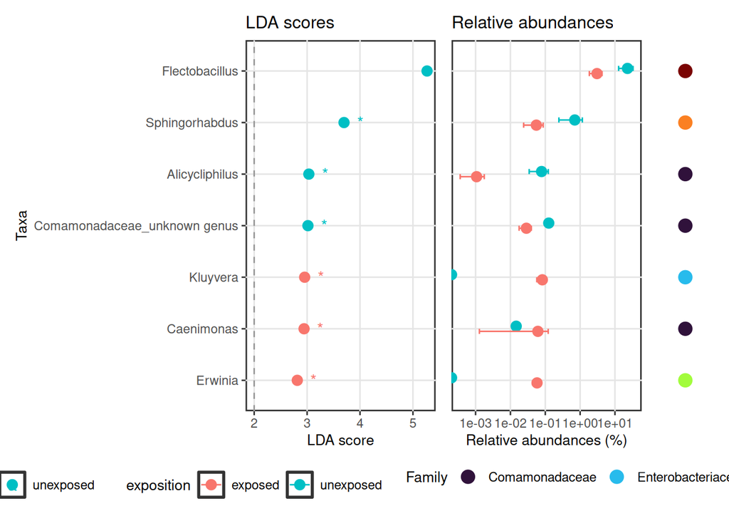

```r
# set up taxonomy
tax_levels <- c("Phylum", "Class", "Order", "Family", "Genus")
fill_unknowns <- function(tax_row, tax_levels) {
  for(i in seq_along(tax_levels)) {
    level <- tax_levels[i]
    if(tax_row[[level]] == "unknown" | grepl("unknown", tax_row[[level]])) {
      if(i == 1) {
        # Premier niveau
        tax_row[[level]] <- paste0("unknown ", tolower(level))
      } else {
        # Concatène avec le niveau précédent
        prev_val <- tax_row[[tax_levels[i-1]]]
        tax_row[[level]] <- paste0(prev_val, "_unknown ", tolower(level))
      }
    }
  }
  tax_row
}

# Run LEFSE
tax_level <- "Genus"
set.seed(123)
lefse_res <- run_lefse(rdata_L_genus, "exposition",
  taxa_rank = rank_names(rdata_L_genus)[6],
  lda_cutoff = 2,              # minimum LDA score to consider
  norm = "CPM",
  kw_cutoff = 0.05             # Kruskal-Wallis p-value cutoff
  )
lda_results <- marker_table(lefse_res)

pvals <- lda_results$pvalue
lda_results$padj_check <- p.adjust(pvals, method = "BH")
lda_filtered <- lda_results[lda_results$padj_check <= 0.05, ]
lda_filtered$padj_star <- ifelse(
  is.na(lda_filtered$padj_check), "NS",
  ifelse(lda_filtered$padj_check < 0.001, "***",
         ifelse(lda_filtered$padj_check < 0.01, "**",
                ifelse(lda_filtered$padj_check < 0.05, "*", "NS")))
)

# Exact order of taxa according to LDA score
lda_df <- data.frame(
  feature = lda_filtered$feature,
  ef_lda = lda_filtered$ef_lda,
  enrich_group = lda_filtered$enrich_group,
  padj_star = lda_filtered$padj_star
)
lda_order <- lda_df %>%
  arrange(ef_lda) %>%
  pull(feature)

# plot LDA scores
p1 <- ggplot(lda_df, aes(x = reorder(feature, ef_lda), y = ef_lda,
                         fill = enrich_group, color = enrich_group)) +
  geom_point(size = 3) +
  geom_text(aes(label = padj_star),
            hjust = ifelse(lda_df$ef_lda > 2, -2, 1),
            size = 4) +
  coord_flip() +
  geom_hline(yintercept = 2, linetype = "dashed", color = "gray60") +
  labs(x = "Taxa", y = "LDA score",
       title = "LDA scores") +
  theme(legend.position = "bottom",
        title = element_text(size=10),
        panel.background = element_rect(fill = "white", colour = "gray20", linewidth = 1, linetype = "solid"),
        panel.grid.major = element_line(size = 0.5, linetype = 'solid', colour = "gray90"),
        panel.grid.minor = element_blank())


# Set up abundances
meta_df <- as.data.frame(sample_data(rdata_L_genus))
meta_df$SampleID <- rownames(meta_df)
meta_df <- meta_df[, c("SampleID", "exposition")]

otu_mat <- as.matrix(otu_table(rdata_L_genus))
if(!taxa_are_rows(rdata_L_genus)) otu_mat <- t(otu_mat)
otu_rel <- sweep(otu_mat, 2, colSums(otu_mat), FUN = "/") * 100

tax_df_full <- as.data.frame(tax_table(rdata_L_genus))
tax_df_full$OTU_ID <- rownames(tax_df_full)

tax_df_full_ok <- tax_df_full %>%
  rowwise() %>%
  do(as_tibble(fill_unknowns(as.list(.), tax_levels))) %>%
  ungroup()

tax_df_sig <- tax_df_full_ok %>%
  dplyr::filter(.data[[tax_level]] %in% lda_order)

tax_df_sig <- tax_df_sig %>%
  dplyr::group_by(.data[[tax_level]]) %>%
  dplyr::summarise(
    Family = unique(Family),
    Phylum = unique(Phylum),
    .groups = "drop"
  )

otu_mat <- as.matrix(otu_table(rdata_L_genus))
if (!taxa_are_rows(rdata_L_genus)) otu_mat <- t(otu_mat)

otu_rel <- sweep(otu_mat, 2, colSums(otu_mat), FUN = "/") * 100

sig_otus <- tax_df_full_ok$OTU_ID[
  tax_df_full_ok[[tax_level]] %in% tax_df_sig[[tax_level]]
]
otu_rel_sig <- otu_rel[rownames(otu_rel) %in% sig_otus, , drop = FALSE]

df_long <- data.frame(
  SampleID = rep(colnames(otu_rel_sig), each = nrow(otu_rel_sig)),
  OTU_ID = rep(rownames(otu_rel_sig), times = ncol(otu_rel_sig)),
  rel_ab = as.vector(otu_rel_sig)
) %>%
  dplyr::left_join(meta_df, by = "SampleID") %>%
  dplyr::left_join(tax_df_full_ok[, c("OTU_ID", tax_level)], by = "OTU_ID") %>%
  dplyr::group_by(taxon = .data[[tax_level]], exposition) %>%
  dplyr::summarise(
    mean_ab = mean(rel_ab),
    se_ab = sd(rel_ab)/sqrt(n()),
    .groups = "drop"
  ) %>%
  dplyr::left_join(tax_df_sig, by = c("taxon" = tax_level)) %>%
  dplyr::mutate(taxon = factor(taxon, levels = lda_order))

# plot abundances
p2 <- ggplot(df_long, aes(x = mean_ab, y = taxon, color = exposition)) +
  geom_point(size = 3, position = position_dodge(width = 0.2)) +
  geom_errorbarh(aes(xmin = mean_ab - se_ab, xmax = mean_ab + se_ab),
                 height = 0.2, position = position_dodge(width = 0.2)) +
  labs(x = "Relative abundances (%)", y = NULL,
       title = "Relative abundances") +
  ylab(NULL) +
  theme(axis.text.y = element_blank(),
        axis.ticks.y = element_blank(),
        legend.position = "bottom",
        title = element_text(size=10),
        panel.background = element_rect(fill = "white", colour = "gray20", linewidth = 1, linetype = "solid"),
        panel.grid.major = element_line(size = 0.5, linetype = 'solid', colour = "gray90"),
        panel.grid.minor = element_blank()) +
  scale_x_log10()

# plot taxo info
taxon_phylum <- df_long %>%
  distinct(taxon, Family)

p3 <- ggplot(taxon_phylum,
             aes(x = 1, y = taxon, color = Family)) +
  geom_point(size = 4) +
  scale_color_viridis_d(option = "turbo", name = "Family") +
  theme_void() +
  theme(
    legend.position = "bottom",
    legend.title = element_text(size = 10),
    legend.text = element_text(size = 9),
    plot.margin = margin(5, 5, 5, 5)
  ) +
  xlim(0.5, 1.5)

# combine
combined_plot <- p1 + p2 + p3 +
  plot_layout(ncol = 3, widths = c(1, 1, 0.3), guides = "collect") &
  theme(legend.position = "bottom")
```

## 1.2. log2(fold change) according to exposure

```
load("rdata_LARVES_genus.RData")
```

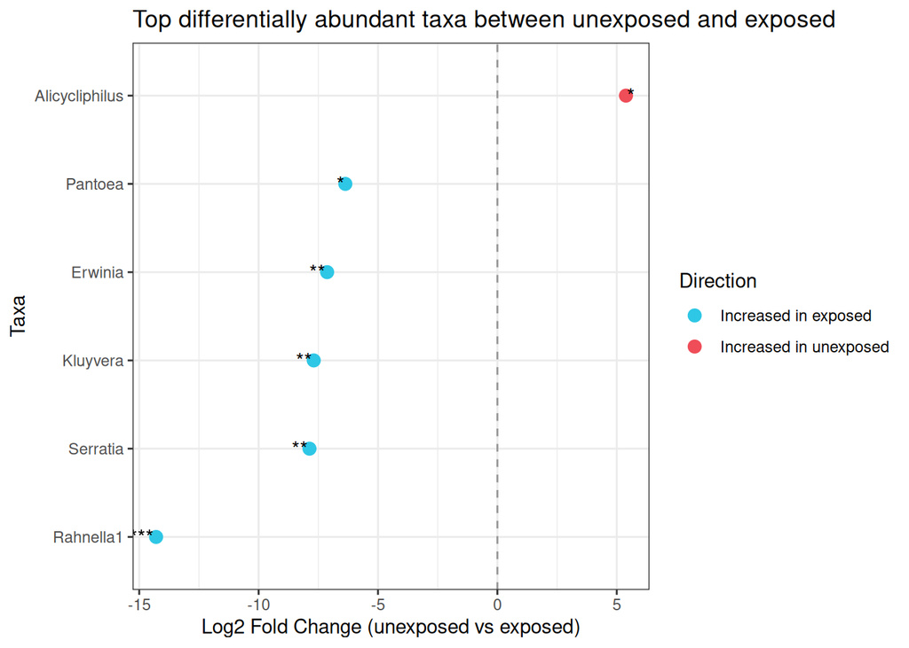

```r
dds <- phyloseq_to_deseq2(rdata_L_genus, ~ exposition)
dds <- DESeq(dds, sfType = "poscounts")
res <- results(dds, contrast = c("exposition", "unexposed", "exposed"))

top_changes <- res[res$padj < 0.05 & !is.na(res$padj), ]
tax_table_df <- as.data.frame(tax_table(rdata_L_genus))
top_changes$taxa <- rownames(top_changes)
top_changes$genus <- tax_table_df[top_changes$taxa, "Genus"]
top_changes$genus <- factor(
  top_changes$genus,
  levels = unique(top_changes$genus[order(top_changes$log2FoldChange)])
)

top_changes$padj_star <- ifelse(is.na(top_changes$padj), "NS",
                          ifelse(top_changes$padj < 0.001, "***",
                          ifelse(top_changes$padj < 0.01, "**",
                          ifelse(top_changes$padj < 0.05, "*", "NS"))))

plot <- ggplot(top_changes, aes(x = genus, y = log2FoldChange, color = log2FoldChange > 0)) +
  geom_point(size=3) +
  geom_text(aes(label = padj_star),
            hjust = ifelse(top_changes$log2FoldChange > 0, -0.1, 1.1),
            size = 4,
            color = "black") +
  coord_flip() +
  geom_hline(yintercept = 0, linetype = "dashed", color = "gray60") +
  labs(x = "Taxa", y = "Log2 Fold Change (unexposed vs exposed)",
       title = "Top differentially abundant taxa between unexposed and exposed") +
  scale_color_manual(name = "Direction",
                  values = c("FALSE" = "#2ec7e5", "TRUE" = "#ef4d58"),
                  labels = c("Increased in exposed", "Increased in unexposed")) +
  theme_bw()
```

## 1.3. LDA scores according to concentration categories

### 1.3.1. Unexposed vs other concentrations

Control vs MP60:

```
load("rdata_LARVES.RData")
```

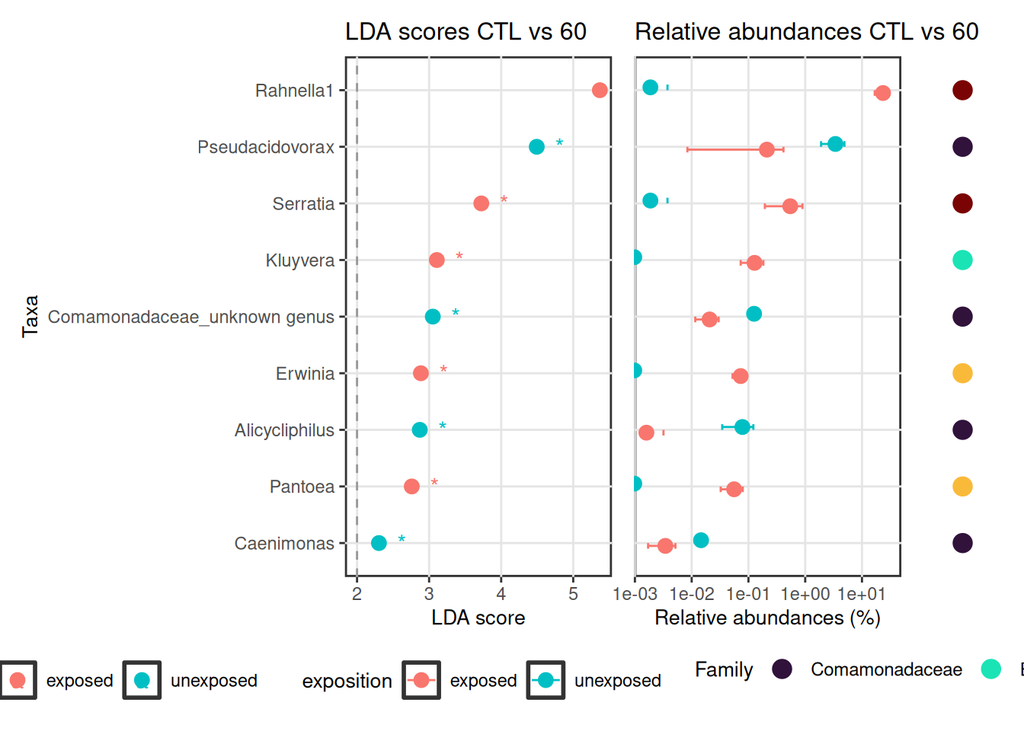

```r
rdata_L_1 <- subset_samples(rdata_L, treatment %in% c("control", "60"))
rdata_L <- prune_taxa(taxa_sums(rdata_L_1) > 0, rdata_L_1)
rdata_L_genus <- tax_glom(rdata_L, taxrank=rank_names(rdata_L)[6])
rdata_L_genus <- phyloseq_rm_na_tax(rdata_L_genus)

# set up taxonomy
tax_levels <- c("Phylum", "Class", "Order", "Family", "Genus")
fill_unknowns <- function(tax_row, tax_levels) {
  for(i in seq_along(tax_levels)) {
    level <- tax_levels[i]
    if(tax_row[[level]] == "unknown" | grepl("unknown", tax_row[[level]])) {
      if(i == 1) {
        # Premier niveau
        tax_row[[level]] <- paste0("unknown ", tolower(level))
      } else {
        # Concatène avec le niveau précédent
        prev_val <- tax_row[[tax_levels[i-1]]]
        tax_row[[level]] <- paste0(prev_val, "_unknown ", tolower(level))
      }
    }
  }
  tax_row
}

# Run LEFSE
tax_level <- "Genus"
set.seed(123)
lefse_res <- run_lefse(rdata_L_genus, "exposition",
  taxa_rank = rank_names(rdata_L_genus)[6],
  lda_cutoff = 2,              # minimum LDA score to consider
  norm = "CPM",
  kw_cutoff = 0.05             # Kruskal-Wallis p-value cutoff
  )
lda_results <- marker_table(lefse_res)

pvals <- lda_results$pvalue
lda_results$padj_check <- p.adjust(pvals, method = "BH")
lda_filtered <- lda_results[lda_results$padj_check <= 0.05, ]
lda_filtered$padj_star <- ifelse(
  is.na(lda_filtered$padj_check), "NS",
  ifelse(lda_filtered$padj_check < 0.001, "***",
         ifelse(lda_filtered$padj_check < 0.01, "**",
                ifelse(lda_filtered$padj_check < 0.05, "*", "NS")))
)

# Exact order of taxa according to LDA score
lda_df <- data.frame(
  feature = lda_filtered$feature,
  ef_lda = lda_filtered$ef_lda,
  enrich_group = lda_filtered$enrich_group,
  padj_star = lda_filtered$padj_star
)
lda_order <- lda_df %>%
  arrange(ef_lda) %>%
  pull(feature)

# plot LDA scores
p1 <- ggplot(lda_df, aes(x = reorder(feature, ef_lda), y = ef_lda,
                         fill = enrich_group, color = enrich_group)) +
  geom_point(size = 3) +
  geom_text(aes(label = padj_star),
            hjust = ifelse(lda_df$ef_lda > 2, -2, 1),
            size = 4) +
  coord_flip() +
  geom_hline(yintercept = 2, linetype = "dashed", color = "gray60") +
  labs(x = "Taxa", y = "LDA score",
       title = "LDA scores CTL vs 60") +
  theme(legend.position = "bottom",
        title = element_text(size=10),
        panel.background = element_rect(fill = "white", colour = "gray20", linewidth = 1, linetype = "solid"),
        panel.grid.major = element_line(size = 0.5, linetype = 'solid', colour = "gray90"),
        panel.grid.minor = element_blank())


# Set up abundances
meta_df <- as.data.frame(sample_data(rdata_L_genus))
meta_df$SampleID <- rownames(meta_df)
meta_df <- meta_df[, c("SampleID", "exposition")]

otu_mat <- as.matrix(otu_table(rdata_L_genus))
if(!taxa_are_rows(rdata_L_genus)) otu_mat <- t(otu_mat)
otu_rel <- sweep(otu_mat, 2, colSums(otu_mat), FUN = "/") * 100

tax_df_full <- as.data.frame(tax_table(rdata_L_genus))
tax_df_full$OTU_ID <- rownames(tax_df_full)

tax_df_full_ok <- tax_df_full %>%
  rowwise() %>%
  do(as_tibble(fill_unknowns(as.list(.), tax_levels))) %>%
  ungroup()

tax_df_sig <- tax_df_full_ok %>%
  dplyr::filter(.data[[tax_level]] %in% lda_order)

tax_df_sig <- tax_df_sig %>%
  dplyr::group_by(.data[[tax_level]]) %>%
  dplyr::summarise(
    Family = unique(Family),
    Phylum = unique(Phylum),
    .groups = "drop"
  )

otu_mat <- as.matrix(otu_table(rdata_L_genus))
if (!taxa_are_rows(rdata_L_genus)) otu_mat <- t(otu_mat)

otu_rel <- sweep(otu_mat, 2, colSums(otu_mat), FUN = "/") * 100

sig_otus <- tax_df_full_ok$OTU_ID[
  tax_df_full_ok[[tax_level]] %in% tax_df_sig[[tax_level]]
]
otu_rel_sig <- otu_rel[rownames(otu_rel) %in% sig_otus, , drop = FALSE]

df_long <- data.frame(
  SampleID = rep(colnames(otu_rel_sig), each = nrow(otu_rel_sig)),
  OTU_ID = rep(rownames(otu_rel_sig), times = ncol(otu_rel_sig)),
  rel_ab = as.vector(otu_rel_sig)
) %>%
  dplyr::left_join(meta_df, by = "SampleID") %>%
  dplyr::left_join(tax_df_full_ok[, c("OTU_ID", tax_level)], by = "OTU_ID") %>%
  dplyr::group_by(taxon = .data[[tax_level]], exposition) %>%
  dplyr::summarise(
    mean_ab = mean(rel_ab),
    se_ab = sd(rel_ab)/sqrt(n()),
    .groups = "drop"
  ) %>%
  dplyr::left_join(tax_df_sig, by = c("taxon" = tax_level)) %>%
  dplyr::mutate(taxon = factor(taxon, levels = lda_order))

# plot abundances
p2 <- ggplot(df_long, aes(x = mean_ab, y = taxon, color = exposition)) +
  geom_point(size = 3, position = position_dodge(width = 0.2)) +
  geom_errorbarh(aes(xmin = mean_ab - se_ab, xmax = mean_ab + se_ab),
                 height = 0.2, position = position_dodge(width = 0.2)) +
  labs(x = "Relative abundances (%)", y = NULL,
       title = "Relative abundances CTL vs 60") +
  ylab(NULL) +
  theme(axis.text.y = element_blank(),
        axis.ticks.y = element_blank(),
        legend.position = "bottom",
        title = element_text(size=10),
        panel.background = element_rect(fill = "white", colour = "gray20", linewidth = 1, linetype = "solid"),
        panel.grid.major = element_line(size = 0.5, linetype = 'solid', colour = "gray90"),
        panel.grid.minor = element_blank()) +
  scale_x_log10()

# plot taxo info
taxon_phylum <- df_long %>%
  distinct(taxon, Family)

p3 <- ggplot(taxon_phylum,
             aes(x = 1, y = taxon, color = Family)) +
  geom_point(size = 4) +
  scale_color_viridis_d(option = "turbo", name = "Family") +
  theme_void() +
  theme(
    legend.position = "bottom",
    legend.title = element_text(size = 10),
    legend.text = element_text(size = 9),
    plot.margin = margin(5, 5, 5, 5)
  ) +
  xlim(0.5, 1.5)

# combine
combined_plot_1 <- p1 + p2 + p3 +
  plot_layout(ncol = 3, widths = c(1, 1, 0.3), guides = "collect") &
  theme(legend.position = "bottom")
```

Control vs MP200 & Control vs MP600 were tested using similar command lines.

### 1.3.2. Concentration vs concentration

MP200 vs MP600:

```
load("rdata_LARVES.RData")
```

```r
rdata_L_1 <- subset_samples(rdata_L, treatment %in% c("200", "600"))
rdata_L <- prune_taxa(taxa_sums(rdata_L_1) > 0, rdata_L_1)
rdata_L_genus <- tax_glom(rdata_L, taxrank=rank_names(rdata_L)[6])
rdata_L_genus <- phyloseq_rm_na_tax(rdata_L_genus)

# set up taxonomy
tax_levels <- c("Phylum", "Class", "Order", "Family", "Genus")
fill_unknowns <- function(tax_row, tax_levels) {
  for(i in seq_along(tax_levels)) {
    level <- tax_levels[i]
    if(tax_row[[level]] == "unknown" | grepl("unknown", tax_row[[level]])) {
      if(i == 1) {
        # Premier niveau
        tax_row[[level]] <- paste0("unknown ", tolower(level))
      } else {
        # Concatène avec le niveau précédent
        prev_val <- tax_row[[tax_levels[i-1]]]
        tax_row[[level]] <- paste0(prev_val, "_unknown ", tolower(level))
      }
    }
  }
  tax_row
}

# Run LEFSE
tax_level <- "Genus"
set.seed(123)
lefse_res <- run_lefse(rdata_L_genus, "treatment",
  taxa_rank = rank_names(rdata_L_genus)[6],
  lda_cutoff = 2,              # minimum LDA score to consider
  norm = "CPM",
  kw_cutoff = 0.05             # Kruskal-Wallis p-value cutoff
  )
lda_results <- marker_table(lefse_res)
```

MP60 vs MP200 & MP60 vs MP600 were tested using similar command lines.

## 1.4. log2(fold change) according to concentration categories

### 1.4.1. Unexposed vs other concentrations

CTL vs MP60:

```
load("rdata_LARVES.RData")
```

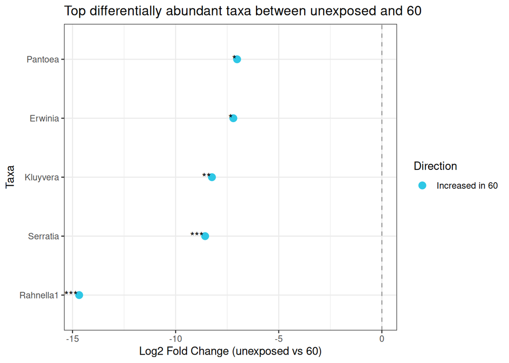

```r
rdata_L_1 <- subset_samples(rdata_L, treatment %in% c("control", "60"))
rdata_L <- prune_taxa(taxa_sums(rdata_L_1) > 0, rdata_L_1)
rdata_L_genus <- tax_glom(rdata_L, taxrank=rank_names(rdata_L)[6])
rdata_L_genus <- phyloseq_rm_na_tax(rdata_L_genus)
rdata_L_genus -> rdata

dds <- phyloseq_to_deseq2(rdata, ~ exposition)
dds <- DESeq(dds, sfType = "poscounts")
res <- results(dds, contrast = c("exposition", "unexposed", "exposed"))

top_changes <- res[res$padj < 0.05 & !is.na(res$padj), ]
tax_table_df <- as.data.frame(tax_table(rdata))
top_changes$taxa <- rownames(top_changes)
top_changes$genus <- tax_table_df[top_changes$taxa, "Genus"]
top_changes$genus <- factor(
  top_changes$genus,
  levels = unique(top_changes$genus[order(top_changes$log2FoldChange)])
)

top_changes$padj_star <- ifelse(is.na(top_changes$padj), "NS",
                          ifelse(top_changes$padj < 0.001, "***",
                          ifelse(top_changes$padj < 0.01, "**",
                          ifelse(top_changes$padj < 0.05, "*", "NS"))))

plot1 <- ggplot(top_changes, aes(x = genus, y = log2FoldChange, color = log2FoldChange > 0)) +
  geom_point(size=3) +
  geom_text(aes(label = padj_star),
            hjust = ifelse(top_changes$log2FoldChange > 0, -0.1, 1.1),
            size = 4,
            color = "black") +
  coord_flip() +
  geom_hline(yintercept = 0, linetype = "dashed", color = "gray60") +
  labs(x = "Taxa", y = "Log2 Fold Change (unexposed vs 60)",
       title = "Top differentially abundant taxa between unexposed and 60") +
  scale_color_manual(name = "Direction",
                  values = c("FALSE" = "#2ec7e5", "TRUE" = "#ef4d58"),
                  labels = c("Increased in 60", "Increased in unexposed")) +
  theme_bw()
```

CTL vs MP200 & CTL vs MP600 were tested using similar command lines.

### 1.4.2. Concentration vs concentration

MP60 vs MP200:

```
load("rdata_LARVES.RData")
```

```r
rdata_L_1 <- subset_samples(rdata_L, treatment %in% c("60", "200"))
rdata_L <- prune_taxa(taxa_sums(rdata_L_1) > 0, rdata_L_1)
rdata_L_genus <- tax_glom(rdata_L, taxrank=rank_names(rdata_L)[6])
rdata_L_genus <- phyloseq_rm_na_tax(rdata_L_genus)
rdata_L_genus -> rdata

dds <- phyloseq_to_deseq2(rdata, ~ treatment)
dds <- DESeq(dds, sfType = "poscounts")
res <- results(dds, contrast = c("treatment", "60", "200"))

top_changes <- res[res$padj < 0.05 & !is.na(res$padj), ]
```

MP60 vs MP600 & MP200 vs MP600 were tested using similar command lines.

**Similar command lines were used to analyse the whole females and female midguts’ datasets.**

# 2. Focus on Wolbachia and Elizabethkingia

## 2.1. How many in unexposed samples?

First, **we create a dataframe setting out the metadata and relative abundance for each OTU per unexposed sample**:

```r
genera_of_interest <- c(
  "Wolbachia",
  "Elizabethkingia"
)

# extract values
extract_genus_rel_abundance <- function(physeq_rel, genus_name) {

  tax <- as.data.frame(tax_table(physeq_rel))
  abund <- as.data.frame(otu_table(physeq_rel))

  # get OTUs (cluster_x) belonging to that genus
  taxa_interest <- rownames(tax)[tax$Genus == genus_name]

  # if genus not found, return an empty dataframe
  if (length(taxa_interest) == 0) {
    warning(paste("No OTU found for genus:", genus_name))
    return(data.frame())
  }

  # subset abundance table
  taxa_abund <- abund[taxa_interest, , drop = FALSE]

  # sum all OTUs of that genus per sample
  taxa_rel <- colSums(taxa_abund)

  # build clean dataframe
  df <- data.frame(
    sample = names(taxa_rel),
    value = taxa_rel,
    row.names = NULL
  )

  colnames(df)[2] <- paste0(genus_name)

  return(df)
}

list_of_dfs <- lapply(genera_of_interest, function(genus){
  extract_genus_rel_abundance(rdata_ctl_genus_rel, genus)
})

df_rel <- metadata_ctl
df_rel$sample <- rownames(df_rel)
for (df in list_of_dfs) {
  df_rel <- left_join(df_rel, df, by = "sample")
}

# create df for each genus with 0 removed
split_by_genus <- function(df, genera, threshold = 0) {
  lapply(genera, function(genus) {

    if (!genus %in% colnames(df)) {
      warning(paste("Genus not found:", genus))
      return(NULL)
    }

    df %>%
      filter(.data[[genus]] > threshold)
  }) |>
    setNames(genera)
}
df_by_genus <- split_by_genus(df_rel, genera_of_interest)

#df_genus_no0 <- df_by_genus$genus

df_rel$SampleID <- rownames(df_rel)
df_rel_graph <- pivot_longer(df_rel, cols = c(
  "Wolbachia",
  "Elizabethkingia"
), names_to = "OTU_type", values_to = "relative_abundance", values_drop_na = FALSE)
```

From the previous dataframe, we built prevalence and mean relative abundance summaries:

```r
otu_col <- c(
  "Wolbachia",
  "Elizabethkingia"
)
compute_stats_for_otu <- function(df, otu_col, group_var = "sample_type") {

  # prevalence
  df_prev <- df %>%
    group_by(.data[[group_var]]) %>%
    summarise(
      n_total = n(),
      n_infected = sum(.data[[otu_col]] > 0, na.rm = TRUE),
      prevalence = n_infected / n_total,
      .groups = "drop"
    )

  # mean + SE (only positives)
  df_mean <- df %>%
    filter(.data[[otu_col]] > 0) %>%
    group_by(.data[[group_var]]) %>%
    summarise(
      mean_rel_abund = mean(.data[[otu_col]], na.rm = TRUE),
      se_rel_abund = sd(.data[[otu_col]], na.rm = TRUE) / sqrt(n()),
      .groups = "drop"
    )

  # combine
  df_summary <- left_join(df_prev, df_mean, by = group_var)

  # add OTU id
  df_summary$OTU <- otu_col

  return(df_summary)
}

summary_list <- lapply(otu_col, function(otu){
  compute_stats_for_otu(df_rel, otu)
})

df_all_summaries <- bind_rows(summary_list)

kable(df_all_summaries, caption = "Metrics about Wolbachia and Elizabethkingia in unexposed samples", align = "lllllll")
```

Metrics about Wolbachia and Elizabethkingia in unexposed samples

| sample_type | n_total | n_infected | prevalence | mean_rel_abund | se_rel_abund | OTU |
| --- | --- | --- | --- | --- | --- | --- |
| larvae_whole | 3 | 3 | 1.0000000 | 0.0009159 | 0.0003313 | Wolbachia |
| female_whole | 3 | 3 | 1.0000000 | 0.8592331 | 0.1055458 | Wolbachia |
| female_midgut | 9 | 9 | 1.0000000 | 0.7114931 | 0.1228535 | Wolbachia |
| larvae_whole | 3 | 2 | 0.6666667 | 0.0488610 | 0.0487486 | Elizabethkingia |
| female_whole | 3 | 1 | 0.3333333 | 0.3297305 | NA | Elizabethkingia |
| female_midgut | 9 | 0 | 0.0000000 | NA | NA | Elizabethkingia |

## 2.2. In larvae dataset

First, **we create a dataframe setting out the metadata and relative abundance for each OTU per sample**::

```
load("rdata_LARVES_genus_rel.RData")
```

```r
genera_of_interest <- c(
  "Wolbachia",
  "Elizabethkingia"
)

# extract values
extract_genus_rel_abundance <- function(physeq_rel, genus_name) {

  tax <- as.data.frame(tax_table(physeq_rel))
  abund <- as.data.frame(otu_table(physeq_rel))

  # get OTUs (cluster_x) belonging to that genus
  taxa_interest <- rownames(tax)[tax$Genus == genus_name]

  # if genus not found, return an empty dataframe
  if (length(taxa_interest) == 0) {
    warning(paste("No OTU found for genus:", genus_name))
    return(data.frame())
  }

  # subset abundance table
  taxa_abund <- abund[taxa_interest, , drop = FALSE]

  # sum all OTUs of that genus per sample
  taxa_rel <- colSums(taxa_abund)

  # build clean dataframe
  df <- data.frame(
    sample = names(taxa_rel),
    value = taxa_rel,
    row.names = NULL
  )

  colnames(df)[2] <- paste0(genus_name)

  return(df)
}

list_of_dfs <- lapply(genera_of_interest, function(genus){
  extract_genus_rel_abundance(rdata_L_genus_rel, genus)
})

df_rel <- metadata_L
df_rel$sample <- rownames(df_rel)
for (df in list_of_dfs) {
  df_rel <- left_join(df_rel, df, by = "sample")
}

# create df for each genus with 0 removed
split_by_genus <- function(df, genera, threshold = 0) {
  lapply(genera, function(genus) {

    if (!genus %in% colnames(df)) {
      warning(paste("Genus not found:", genus))
      return(NULL)
    }

    df %>%
      filter(.data[[genus]] > threshold)
  }) |>
    setNames(genera)
}
df_by_genus <- split_by_genus(df_rel, genera_of_interest)

#df_genus_no0 <- df_by_genus$genus

df_rel$SampleID <- rownames(df_rel)
df_rel_graph <- pivot_longer(df_rel, cols = c(
  "Wolbachia",
  "Elizabethkingia"
), names_to = "OTU_type", values_to = "relative_abundance", values_drop_na = FALSE)
```

From the previous dataframe, we built prevalence and mean relative abundance summaries:

```r
otu_col <- c(
  "Wolbachia",
  "Elizabethkingia"
)
compute_stats_for_otu <- function(df, otu_col, group_var = "exposition") {

  # prevalence
  df_prev <- df %>%
    group_by(.data[[group_var]]) %>%
    summarise(
      n_total = n(),
      n_infected = sum(.data[[otu_col]] > 0, na.rm = TRUE),
      prevalence = n_infected / n_total,
      .groups = "drop"
    )

  # mean + SE (only positives)
  df_mean <- df %>%
    filter(.data[[otu_col]] > 0) %>%
    group_by(.data[[group_var]]) %>%
    summarise(
      mean_rel_abund = mean(.data[[otu_col]], na.rm = TRUE),
      se_rel_abund = sd(.data[[otu_col]], na.rm = TRUE) / sqrt(n()),
      .groups = "drop"
    )

  # combine
  df_summary <- left_join(df_prev, df_mean, by = group_var)

  # add OTU id
  df_summary$OTU <- otu_col

  return(df_summary)
}

summary_list <- lapply(otu_col, function(otu){
  compute_stats_for_otu(df_rel, otu)
})

df_all_summaries <- bind_rows(summary_list)
```

Plot:

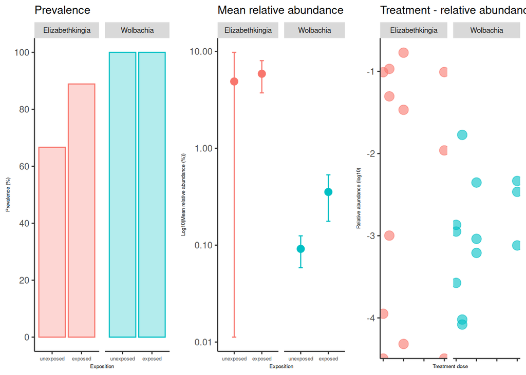

```r
strip_names <- setNames(genera_of_interest, otu_col)

pA <- ggplot(df_all_summaries, aes(x = exposition,fill = OTU, color = OTU)) +
  geom_col(aes(y = prevalence * 100), alpha = 0.3) +
scale_y_continuous(
    name = "Prevalence (%)",
    limits = c(0, 100),
    breaks = seq(0, 100, 20)) +
  labs(
    title = "Prevalence",
    x = "Exposition"
  ) +
  theme(legend.position = "none",
        title = element_text(size=9),
        panel.background = element_rect(fill = "white"),
        panel.grid.major = element_blank(),
        panel.grid.minor = element_blank(),
        axis.line = element_line(color = "gray20", linewidth = 0.5),
        axis.title = element_text(size=5),
        axis.text.x = element_text(size=5),
        strip.text = element_text(size = 7)) +
  facet_wrap(~ OTU, labeller = labeller(OTU = strip_names))

pB <- ggplot(df_all_summaries, aes(x = exposition,fill = OTU, color = OTU)) +
  geom_point(aes(y = mean_rel_abund * 100), size = 3) +
  geom_errorbar(
    aes(ymin = (mean_rel_abund - se_rel_abund)*100,
        ymax = (mean_rel_abund + se_rel_abund)*100), width = 0.15) +
  scale_y_log10(name = "Log10(Mean relative abundance (%))") +
  labs(
    title = "Mean relative abundance",
    x = "Exposition"
  ) +
  theme(legend.position = "none",
        title = element_text(size=9),
        panel.background = element_rect(fill = "white"),
        panel.grid.major = element_blank(),
        panel.grid.minor = element_blank(),
        axis.line = element_line(color = "gray20", linewidth = 0.5),
        axis.title = element_text(size=5),
        axis.text.x = element_text(size=5),
        strip.text = element_text(size = 7)) +
  facet_wrap(~ OTU, labeller = labeller(OTU = strip_names))

pC <- ggplot(df_rel_graph, aes(x= treatment, y = log_rel, fill = OTU_type, color = OTU_type)) +
  geom_point(alpha = 0.6, size = 4,)  +
  labs(
    title = "Treatment - relative abundance correlation",
    x = "Treatment dose",
    y = "Relative abundance (log10)"
  ) +
  theme(legend.position = "none",
        title = element_text(size=9),
        panel.background = element_rect(fill = "white"),
        panel.grid.major = element_blank(),
        panel.grid.minor = element_blank(),
        axis.line = element_line(color = "gray20", linewidth = 0.5),
        axis.title = element_text(size=5),
        axis.text.x = element_blank(),
        legend.text = element_text(size=5),
        strip.text = element_text(size = 7)) +
  facet_wrap(~ OTU_type, labeller = labeller(OTU_type = strip_names))

combined_plot <- ggarrange(pA, pB, pC, ncol=3)
```

Test about prevalence:

```r
# Fisher test Wolbachia
df_Wolb_summaries <-  df_all_summaries %>%
  filter(OTU == "Wolbachia")
# no test because prevalence is 100% vs 100%


# Fisher test Elizabethkingia
df_Eliz_summaries <-  df_all_summaries %>%
  filter(OTU == "Elizabethkingia")
tab <- with(df_Eliz_summaries,
    {
  matrix(
    c(
      n_infected,
      n_total - n_infected
    ),
    nrow = nrow(df_Eliz_summaries),
    byrow = FALSE,
    dimnames = list(
      exposition,
      c("infected", "not_infected")
    )
  )
})
fisher.test(tab)
```

```
##
##  Fisher's Exact Test for Count Data
##
## data:  tab
## p-value = 0.4545
## alternative hypothesis: true odds ratio is not equal to 1
## 95 percent confidence interval:
##   0.002848937 29.360803313
## sample estimates:
## odds ratio
##  0.2887006
```

Test about relative abundance according exposure:

```r
# Wolbachia
df_Wolb <- df_by_genus$Wolbachia
df_Wolb_no0 <- df_Wolb %>%
  filter(Wolbachia > 0)
wilcox.test(Wolbachia ~ exposition, data = df_Wolb_no0)
```

```
##
##  Wilcoxon rank sum exact test
##
## data:  Wolbachia by exposition
## W = 12, p-value = 0.8636
## alternative hypothesis: true location shift is not equal to 0
```

```r
# Elizabethkingia
df_Eliz <- df_by_genus$Elizabethkingia
df_Eliz_no0 <- df_Eliz %>%
  filter(Elizabethkingia > 0)
wilcox.test(Elizabethkingia ~ exposition, data = df_Eliz_no0)
```

```
##
##  Wilcoxon rank sum exact test
##
## data:  Elizabethkingia by exposition
## W = 6, p-value = 0.7111
## alternative hypothesis: true location shift is not equal to 0
```

Test about relative abundance according concentration (correlation):

```r
# Wolbachia
df_Wolb_no0 <- df_Wolb_no0 %>%
  mutate(treatment = recode(treatment, control = "0"))
df_Wolb_no0$treatment <- as.numeric(as.character(df_Wolb_no0$treatment))
df_Wolb_no0$log_inf <- log10(df_Wolb_no0$Wolbachia)

cor.test(df_Wolb_no0$treatment, df_Wolb_no0$log_inf, method = "spearman")
```

```
##
##  Spearman's rank correlation rho
##
## data:  df_Wolb_no0$treatment and df_Wolb_no0$log_inf
## S = 205.72, p-value = 0.3768
## alternative hypothesis: true rho is not equal to 0
## sample estimates:
##       rho
## 0.2806918
```

```r
# Elizabethkingia
df_Eliz_no0 <- df_Eliz_no0 %>%
  mutate(treatment = recode(treatment, control = "0"))
df_Eliz_no0$treatment <- as.numeric(as.character(df_Eliz_no0$treatment))
df_Eliz_no0$log_inf <- log10(df_Eliz_no0$Elizabethkingia)

cor.test(df_Eliz_no0$treatment, df_Eliz_no0$log_inf, method = "spearman")
```

```
##
##  Spearman's rank correlation rho
##
## data:  df_Eliz_no0$treatment and df_Eliz_no0$log_inf
## S = 146.43, p-value = 0.7569
## alternative hypothesis: true rho is not equal to 0
## sample estimates:
##      rho
## 0.112555
```

```
load("rdata_LARVES_genus.RData")
```

```r
tax_table_df <- as.data.frame(tax_table(rdata_L_genus))

otu_list <- unlist(
  lapply(genera_of_interest, function(genus) {
    rownames(tax_table_df)[tax_table_df$Genus == genus]
  }),
  use.names = FALSE
)

# exposition
dds <- phyloseq_to_deseq2(rdata_L_genus, ~ exposition)
dds <- DESeq(dds, sfType = "poscounts")
res <- results(dds, contrast = c("exposition", "exposed", "unexposed"))
res_subset <- res[rownames(res) %in% otu_list, ]
res_subset$taxa <- rownames(res_subset)
res_subset$genus <- tax_table_df[res_subset$taxa, "Genus"]
res_subset$genus <- factor(
  res_subset$genus,
  levels = unique(res_subset$genus[order(res_subset$log2FoldChange)])
)
res_subset$padj_star <- ifelse(is.na(res_subset$padj), "NS",
                          ifelse(res_subset$padj < 0.001, "***",
                          ifelse(res_subset$padj < 0.01, "**",
                          ifelse(res_subset$padj < 0.05, "*", "NS"))))

fd_exp <- as.data.frame(res_subset@listData)
fd_exp$condition <- "unexposed_vs_exposed"

# exposition considering treatment dose
## 60
rdata_A_1 <- subset_samples(rdata_L_genus, treatment %in% c("60", "control"))
rdata_A <- prune_taxa(taxa_sums(rdata_A_1) > 0, rdata_A_1)
dds <- phyloseq_to_deseq2(rdata_A, ~ exposition)
dds <- DESeq(dds, sfType = "poscounts")
res <- results(dds, contrast = c("exposition", "exposed", "unexposed"))
res_subset <- res[rownames(res) %in% otu_list, ]
res_subset$taxa <- rownames(res_subset)
res_subset$genus <- tax_table_df[res_subset$taxa, "Genus"]
res_subset$padj_star <- ifelse(is.na(res_subset$padj), "NS",
                          ifelse(res_subset$padj < 0.001, "***",
                          ifelse(res_subset$padj < 0.01, "**",
                          ifelse(res_subset$padj < 0.05, "*", "NS"))))
fd_exp_60 <- as.data.frame(res_subset@listData)
fd_exp_60$condition <- "control_vs_60"

## 200
rdata_A_1 <- subset_samples(rdata_L_genus, treatment %in% c("200", "control"))
rdata_A <- prune_taxa(taxa_sums(rdata_A_1) > 0, rdata_A_1)
dds <- phyloseq_to_deseq2(rdata_A, ~ exposition)
dds <- DESeq(dds, sfType = "poscounts")
res <- results(dds, contrast = c("exposition", "exposed", "unexposed"))
res_subset <- res[rownames(res) %in% otu_list, ]
res_subset$taxa <- rownames(res_subset)
res_subset$genus <- tax_table_df[res_subset$taxa, "Genus"]
res_subset$padj_star <- ifelse(is.na(res_subset$padj), "NS",
                          ifelse(res_subset$padj < 0.001, "***",
                          ifelse(res_subset$padj < 0.01, "**",
                          ifelse(res_subset$padj < 0.05, "*", "NS"))))
fd_exp_200 <- as.data.frame(res_subset@listData)
fd_exp_200$condition <- "control_vs_200"

## 600
rdata_A_1 <- subset_samples(rdata_L_genus, treatment %in% c("600", "control"))
rdata_A <- prune_taxa(taxa_sums(rdata_A_1) > 0, rdata_A_1)
dds <- phyloseq_to_deseq2(rdata_A, ~ exposition)
dds <- DESeq(dds, sfType = "poscounts")
res <- results(dds, contrast = c("exposition", "exposed", "unexposed"))
res_subset <- res[rownames(res) %in% otu_list, ]
res_subset$taxa <- rownames(res_subset)
res_subset$genus <- tax_table_df[res_subset$taxa, "Genus"]
res_subset$padj_star <- ifelse(is.na(res_subset$padj), "NS",
                          ifelse(res_subset$padj < 0.001, "***",
                          ifelse(res_subset$padj < 0.01, "**",
                          ifelse(res_subset$padj < 0.05, "*", "NS"))))
fd_exp_600 <- as.data.frame(res_subset@listData)
fd_exp_600$condition <- "control_vs_600"

fd_exp_dose <- bind_rows(fd_exp_60, fd_exp_200, fd_exp_600)
fd_exp_dose$genus <- factor(
  fd_exp_dose$genus,
  levels = unique(fd_exp_dose$genus[order(fd_exp_dose$log2FoldChange)])
)
```

Plot:

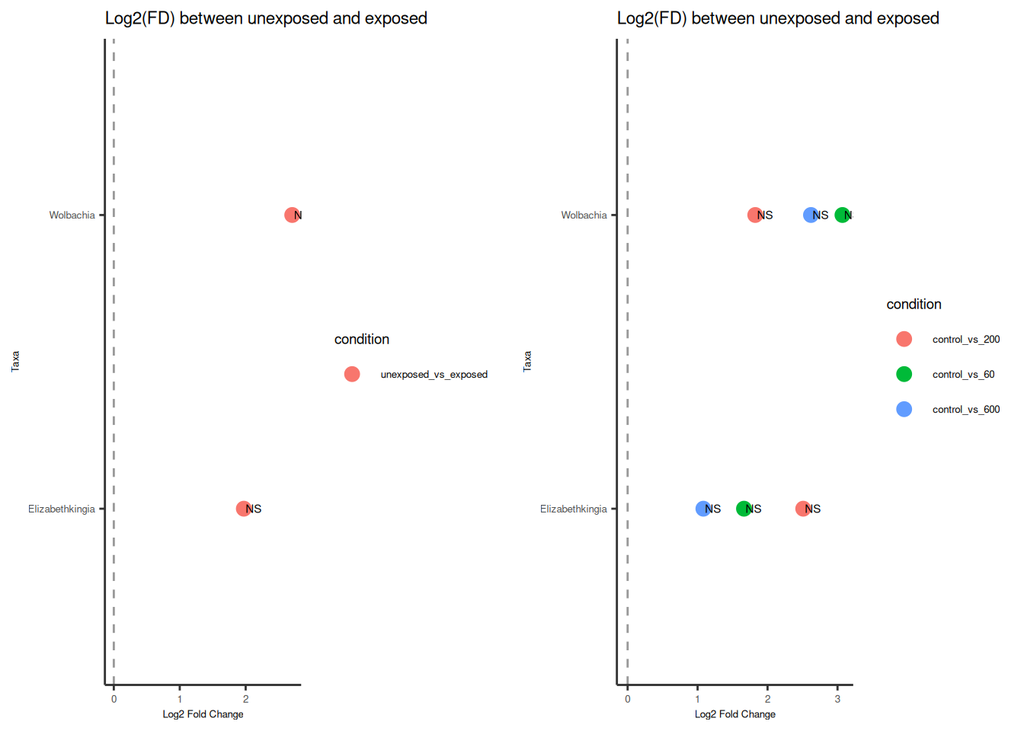

```r
pA <- ggplot(fd_exp, aes(x = genus, y = log2FoldChange, color = condition)) +
  geom_point(size=3) +
  geom_text(aes(label = padj_star),
            hjust = ifelse(fd_exp$log2FoldChange > 0, -0.1, 1.1),
            size = 2,
            color = "black") +
  coord_flip() +
  geom_hline(yintercept = 0, linetype = "dashed", color = "gray60") +
  labs(x = "Taxa", y = "Log2 Fold Change",
       title = "Log2(FD) between unexposed and exposed") +
  theme(legend.position = "right",
        title = element_text(size=7),
        panel.background = element_rect(fill = "white"),
        panel.grid.major = element_blank(),
        panel.grid.minor = element_blank(),
        axis.line = element_line(color = "gray20", linewidth = 0.5),
        axis.title = element_text(size=5),
        axis.text = element_text(size=5),
        legend.text = element_text(size=5))

pB <- ggplot(fd_exp_dose, aes(x = genus, y = log2FoldChange, color = condition)) +
  geom_point(size=3) +
  geom_text(aes(label = padj_star),
            hjust = ifelse(fd_exp_dose$log2FoldChange > 0, -0.1, 1.1),
            size = 2,
            color = "black") +
  coord_flip() +
  geom_hline(yintercept = 0, linetype = "dashed", color = "gray60") +
  labs(x = "Taxa", y = "Log2 Fold Change",
       title = "Log2(FD) between unexposed and exposed") +
  theme(legend.position = "right",
        title = element_text(size=7),
        panel.background = element_rect(fill = "white"),
        panel.grid.major = element_blank(),
        panel.grid.minor = element_blank(),
        axis.line = element_line(color = "gray20", linewidth = 0.5),
        axis.title = element_text(size=5),
        axis.text = element_text(size=5),
        legend.text = element_text(size=5))

combined_plot <- ggarrange(pA, pB, ncol=2)
```

**Similar command lines were used to analyse the whole females and female midguts’ datasets.**

# 3. Descriptive assessments of the genera highlighted by LDA scores and most abundant OTUs in larvae dataset

First, **we create a dataframe setting out the metadata and relative abundance for each OTU per sample**:

```
load("rdata_LARVES_genus_rel.RData")
```

```r
genera_of_interest <- c(
  "Flectobacillus",
  "Sphingorhabdus",
  "Alicycliphilus",
  "Kluyvera",
  "Caenimonas",
  "Erwinia",
  "Pantoea",
  "Serratia",
  "Rahnella1",
  "Pseudacidovorax",
  "Limnohabitans",
  "Comamonas",
  "Enterobacter",
  "Delftia",
  "Nevskia",
  "Flavobacterium",
  "Pseudomonas",
  "Chryseobacterium",
  "Elizabethkingia",
  "Methylophilus"
)

# extract values
extract_genus_rel_abundance <- function(physeq_rel, genus_name) {

  tax <- as.data.frame(tax_table(physeq_rel))
  abund <- as.data.frame(otu_table(physeq_rel))

  # get OTUs (cluster_x) belonging to that genus
  taxa_interest <- rownames(tax)[tax$Genus == genus_name]

  # if genus not found, return an empty dataframe
  if (length(taxa_interest) == 0) {
    warning(paste("No OTU found for genus:", genus_name))
    return(data.frame())
  }

  # subset abundance table
  taxa_abund <- abund[taxa_interest, , drop = FALSE]

  # sum all OTUs of that genus per sample
  taxa_rel <- colSums(taxa_abund)

  # build clean dataframe
  df <- data.frame(
    sample = names(taxa_rel),
    value = taxa_rel,
    row.names = NULL
  )

  colnames(df)[2] <- paste0(genus_name)

  return(df)
}

list_of_dfs <- lapply(genera_of_interest, function(genus){
  extract_genus_rel_abundance(rdata_L_genus_rel, genus)
})

df_rel <- metadata_L
df_rel$sample <- rownames(df_rel)
for (df in list_of_dfs) {
  df_rel <- left_join(df_rel, df, by = "sample")
}

# create df for each genus with 0 removed
split_by_genus <- function(df, genera, threshold = 0) {
  lapply(genera, function(genus) {

    if (!genus %in% colnames(df)) {
      warning(paste("Genus not found:", genus))
      return(NULL)
    }

    df %>%
      filter(.data[[genus]] > threshold)
  }) |>
    setNames(genera)
}
df_by_genus <- split_by_genus(df_rel, genera_of_interest)

df_rel$SampleID <- rownames(df_rel)
df_rel_graph <- pivot_longer(df_rel, cols = c(
  "Flectobacillus",
  "Sphingorhabdus",
  "Alicycliphilus",
  "Kluyvera",
  "Caenimonas",
  "Erwinia",
  "Pantoea",
  "Serratia",
  "Rahnella1",
  "Pseudacidovorax",
  "Limnohabitans",
  "Comamonas",
  "Enterobacter",
  "Delftia",
  "Nevskia",
  "Flavobacterium",
  "Pseudomonas",
  "Chryseobacterium",
  "Elizabethkingia",
  "Methylophilus"
), names_to = "OTU_type", values_to = "relative_abundance", values_drop_na = FALSE)
```

## 3.1. Prevalence and relative abundance

From the previous dataframe, we built prevalence and mean relative abundance summaries:

```r
otu_col <- c(
  "Flectobacillus",
  "Sphingorhabdus",
  "Alicycliphilus",
  "Kluyvera",
  "Caenimonas",
  "Erwinia",
  "Pantoea",
  "Serratia",
  "Rahnella1",
  "Pseudacidovorax",
  "Limnohabitans",
  "Comamonas",
  "Enterobacter",
  "Delftia",
  "Nevskia",
  "Flavobacterium",
  "Pseudomonas",
  "Chryseobacterium",
  "Elizabethkingia",
  "Methylophilus"
)
compute_stats_for_otu <- function(df, otu_col, group_var = "exposition") {

  # prevalence
  df_prev <- df %>%
    group_by(.data[[group_var]]) %>%
    summarise(
      n_total = n(),
      n_infected = sum(.data[[otu_col]] > 0, na.rm = TRUE),
      prevalence = n_infected / n_total,
      .groups = "drop"
    )

  # mean + SE (only positives)
  df_mean <- df %>%
    filter(.data[[otu_col]] > 0) %>%
    group_by(.data[[group_var]]) %>%
    summarise(
      mean_rel_abund = mean(.data[[otu_col]], na.rm = TRUE),
      se_rel_abund = sd(.data[[otu_col]], na.rm = TRUE) / sqrt(n()),
      .groups = "drop"
    )

  # combine
  df_summary <- left_join(df_prev, df_mean, by = group_var)

  # add OTU id
  df_summary$OTU <- otu_col

  return(df_summary)
}

summary_list <- lapply(otu_col, function(otu){
  compute_stats_for_otu(df_rel, otu)
})

df_all_summaries <- bind_rows(summary_list)
```

Plot:

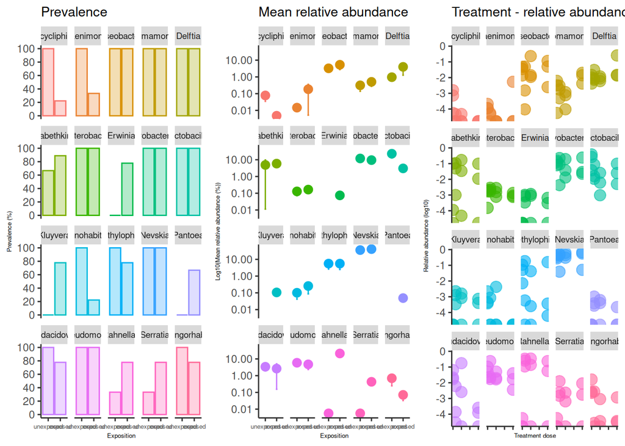

```r
strip_names <- setNames(genera_of_interest, otu_col)

pA <- ggplot(df_all_summaries, aes(x = exposition,fill = OTU, color = OTU)) +
  geom_col(aes(y = prevalence * 100), alpha = 0.3) +
scale_y_continuous(
    name = "Prevalence (%)",
    limits = c(0, 100),
    breaks = seq(0, 100, 20)) +
  labs(
    title = "Prevalence",
    x = "Exposition"
  ) +
  theme(legend.position = "none",
        title = element_text(size=9),
        panel.background = element_rect(fill = "white"),
        panel.grid.major = element_blank(),
        panel.grid.minor = element_blank(),
        axis.line = element_line(color = "gray20", linewidth = 0.5),
        axis.title = element_text(size=5),
        axis.text.x = element_text(size=5),
        strip.text = element_text(size = 7)) +
  facet_wrap(~ OTU, labeller = labeller(OTU = strip_names))

pB <- ggplot(df_all_summaries, aes(x = exposition,fill = OTU, color = OTU)) +
  geom_point(aes(y = mean_rel_abund * 100), size = 3) +
  geom_errorbar(
    aes(ymin = (mean_rel_abund - se_rel_abund)*100,
        ymax = (mean_rel_abund + se_rel_abund)*100), width = 0.15) +
  scale_y_log10(name = "Log10(Mean relative abundance (%))") +
  labs(
    title = "Mean relative abundance",
    x = "Exposition"
  ) +
  theme(legend.position = "none",
        title = element_text(size=9),
        panel.background = element_rect(fill = "white"),
        panel.grid.major = element_blank(),
        panel.grid.minor = element_blank(),
        axis.line = element_line(color = "gray20", linewidth = 0.5),
        axis.title = element_text(size=5),
        axis.text.x = element_text(size=5),
        strip.text = element_text(size = 7)) +
  facet_wrap(~ OTU, labeller = labeller(OTU = strip_names))

pC <- ggplot(df_rel_graph, aes(x= treatment, y = log_rel, fill = OTU_type, color = OTU_type)) +
  geom_point(alpha = 0.6, size = 4,)  +
  labs(
    title = "Treatment - relative abundance correlation",
    x = "Treatment dose",
    y = "Relative abundance (log10)"
  ) +
  theme(legend.position = "none",
        title = element_text(size=9),
        panel.background = element_rect(fill = "white"),
        panel.grid.major = element_blank(),
        panel.grid.minor = element_blank(),
        axis.line = element_line(color = "gray20", linewidth = 0.5),
        axis.title = element_text(size=5),
        axis.text.x = element_blank(),
        legend.text = element_text(size=5),
        strip.text = element_text(size = 7)) +
  facet_wrap(~ OTU_type, labeller = labeller(OTU_type = strip_names))

combined_plot <- ggarrange(pA, pB, pC, ncol=3)
```

## 3.2. log2(fold change) between unexposed vs exposed

Calculate log2(FD):

```
load("rdata_LARVES_genus.RData")
```

```r
tax_table_df <- as.data.frame(tax_table(rdata_L_genus))

otu_list <- unlist(
  lapply(genera_of_interest, function(genus) {
    rownames(tax_table_df)[tax_table_df$Genus == genus]
  }),
  use.names = FALSE
)

# exposition
dds <- phyloseq_to_deseq2(rdata_L_genus, ~ exposition)
dds <- DESeq(dds, sfType = "poscounts")
res <- results(dds, contrast = c("exposition", "exposed", "unexposed"))
res_subset <- res[rownames(res) %in% otu_list, ]
res_subset$taxa <- rownames(res_subset)
res_subset$genus <- tax_table_df[res_subset$taxa, "Genus"]
res_subset$genus <- factor(
  res_subset$genus,
  levels = unique(res_subset$genus[order(res_subset$log2FoldChange)])
)
res_subset$padj_star <- ifelse(is.na(res_subset$padj), "NS",
                          ifelse(res_subset$padj < 0.001, "***",
                          ifelse(res_subset$padj < 0.01, "**",
                          ifelse(res_subset$padj < 0.05, "*", "NS"))))

fd_exp <- as.data.frame(res_subset@listData)
fd_exp$condition <- "unexposed_vs_exposed"

# exposition considering treatment dose
## 60
rdata_A_1 <- subset_samples(rdata_L_genus, treatment %in% c("60", "control"))
rdata_A <- prune_taxa(taxa_sums(rdata_A_1) > 0, rdata_A_1)
dds <- phyloseq_to_deseq2(rdata_A, ~ exposition)
dds <- DESeq(dds, sfType = "poscounts")
res <- results(dds, contrast = c("exposition", "exposed", "unexposed"))
res_subset <- res[rownames(res) %in% otu_list, ]
res_subset$taxa <- rownames(res_subset)
res_subset$genus <- tax_table_df[res_subset$taxa, "Genus"]
res_subset$padj_star <- ifelse(is.na(res_subset$padj), "NS",
                          ifelse(res_subset$padj < 0.001, "***",
                          ifelse(res_subset$padj < 0.01, "**",
                          ifelse(res_subset$padj < 0.05, "*", "NS"))))
fd_exp_60 <- as.data.frame(res_subset@listData)
fd_exp_60$condition <- "control_vs_60"

## 200
rdata_A_1 <- subset_samples(rdata_L_genus, treatment %in% c("200", "control"))
rdata_A <- prune_taxa(taxa_sums(rdata_A_1) > 0, rdata_A_1)
dds <- phyloseq_to_deseq2(rdata_A, ~ exposition)
dds <- DESeq(dds, sfType = "poscounts")
res <- results(dds, contrast = c("exposition", "exposed", "unexposed"))
res_subset <- res[rownames(res) %in% otu_list, ]
res_subset$taxa <- rownames(res_subset)
res_subset$genus <- tax_table_df[res_subset$taxa, "Genus"]
res_subset$padj_star <- ifelse(is.na(res_subset$padj), "NS",
                          ifelse(res_subset$padj < 0.001, "***",
                          ifelse(res_subset$padj < 0.01, "**",
                          ifelse(res_subset$padj < 0.05, "*", "NS"))))
fd_exp_200 <- as.data.frame(res_subset@listData)
fd_exp_200$condition <- "control_vs_200"

## 600
rdata_A_1 <- subset_samples(rdata_L_genus, treatment %in% c("600", "control"))
rdata_A <- prune_taxa(taxa_sums(rdata_A_1) > 0, rdata_A_1)
dds <- phyloseq_to_deseq2(rdata_A, ~ exposition)
dds <- DESeq(dds, sfType = "poscounts")
res <- results(dds, contrast = c("exposition", "exposed", "unexposed"))
res_subset <- res[rownames(res) %in% otu_list, ]
res_subset$taxa <- rownames(res_subset)
res_subset$genus <- tax_table_df[res_subset$taxa, "Genus"]
res_subset$padj_star <- ifelse(is.na(res_subset$padj), "NS",
                          ifelse(res_subset$padj < 0.001, "***",
                          ifelse(res_subset$padj < 0.01, "**",
                          ifelse(res_subset$padj < 0.05, "*", "NS"))))
fd_exp_600 <- as.data.frame(res_subset@listData)
fd_exp_600$condition <- "control_vs_600"

fd_exp_dose <- bind_rows(fd_exp_60, fd_exp_200, fd_exp_600)
fd_exp_dose$genus <- factor(
  fd_exp_dose$genus,
  levels = unique(fd_exp_dose$genus[order(fd_exp_dose$log2FoldChange)])
)
```

Plot:

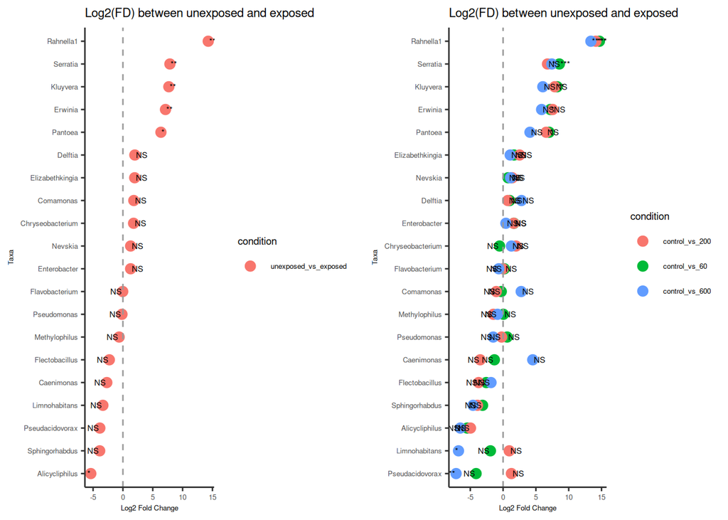

```r
pA <- ggplot(fd_exp, aes(x = genus, y = log2FoldChange, color = condition)) +
  geom_point(size=3) +
  geom_text(aes(label = padj_star),
            hjust = ifelse(fd_exp$log2FoldChange > 0, -0.1, 1.1),
            size = 2,
            color = "black") +
  coord_flip() +
  geom_hline(yintercept = 0, linetype = "dashed", color = "gray60") +
  labs(x = "Taxa", y = "Log2 Fold Change",
       title = "Log2(FD) between unexposed and exposed") +
  theme(legend.position = "right",
        title = element_text(size=7),
        panel.background = element_rect(fill = "white"),
        panel.grid.major = element_blank(),
        panel.grid.minor = element_blank(),
        axis.line = element_line(color = "gray20", linewidth = 0.5),
        axis.title = element_text(size=5),
        axis.text = element_text(size=5),
        legend.text = element_text(size=5))

pB <- ggplot(fd_exp_dose, aes(x = genus, y = log2FoldChange, color = condition)) +
  geom_point(size=3) +
  geom_text(aes(label = padj_star),
            hjust = ifelse(fd_exp_dose$log2FoldChange > 0, -0.1, 1.1),
            size = 2,
            color = "black") +
  coord_flip() +
  geom_hline(yintercept = 0, linetype = "dashed", color = "gray60") +
  labs(x = "Taxa", y = "Log2 Fold Change",
       title = "Log2(FD) between unexposed and exposed") +
  theme(legend.position = "right",
        title = element_text(size=7),
        panel.background = element_rect(fill = "white"),
        panel.grid.major = element_blank(),
        panel.grid.minor = element_blank(),
        axis.line = element_line(color = "gray20", linewidth = 0.5),
        axis.title = element_text(size=5),
        axis.text = element_text(size=5),
        legend.text = element_text(size=5))

combined_plot <- ggarrange(pA, pB, ncol=2)
```

**Similar command lines were used to analyse the whole females’ dataset, with the corresponding list of genera.**

## 3.3. Focus on Pseudacidovorax and Delftia

### 3.3.1. In larvae dataset

First, **we create a dataframe setting out the metadata and relative abundance for each OTU per sample**:

```
load("rdata_LARVES_genus_rel.RData")
```

```r
genera_of_interest <- c(
  "Delftia",
  "Pseudacidovorax"
)

# extract values
extract_genus_rel_abundance <- function(physeq_rel, genus_name) {

  tax <- as.data.frame(tax_table(physeq_rel))
  abund <- as.data.frame(otu_table(physeq_rel))

  # get OTUs (cluster_x) belonging to that genus
  taxa_interest <- rownames(tax)[tax$Genus == genus_name]

  # if genus not found, return an empty dataframe
  if (length(taxa_interest) == 0) {
    warning(paste("No OTU found for genus:", genus_name))
    return(data.frame())
  }

  # subset abundance table
  taxa_abund <- abund[taxa_interest, , drop = FALSE]

  # sum all OTUs of that genus per sample
  taxa_rel <- colSums(taxa_abund)

  # build clean dataframe
  df <- data.frame(
    sample = names(taxa_rel),
    value = taxa_rel,
    row.names = NULL
  )

  colnames(df)[2] <- paste0(genus_name)

  return(df)
}

list_of_dfs <- lapply(genera_of_interest, function(genus){
  extract_genus_rel_abundance(rdata_L_genus_rel, genus)
})

df_rel <- metadata_L
df_rel$sample <- rownames(df_rel)
for (df in list_of_dfs) {
  df_rel <- left_join(df_rel, df, by = "sample")
}

# create df for each genus with 0 removed
split_by_genus <- function(df, genera, threshold = 0) {
  lapply(genera, function(genus) {

    if (!genus %in% colnames(df)) {
      warning(paste("Genus not found:", genus))
      return(NULL)
    }

    df %>%
      filter(.data[[genus]] > threshold)
  }) |>
    setNames(genera)
}
df_by_genus <- split_by_genus(df_rel, genera_of_interest)

#df_genus_no0 <- df_by_genus$genus

df_rel$SampleID <- rownames(df_rel)
df_rel_graph <- pivot_longer(df_rel, cols = c(
  "Delftia",
  "Pseudacidovorax"
), names_to = "OTU_type", values_to = "relative_abundance", values_drop_na = FALSE)
```

From the previous dataframe, we built prevalence and mean relative abundance summaries:

```r
otu_col <- c(
  "Delftia",
  "Pseudacidovorax"
)
compute_stats_for_otu <- function(df, otu_col, group_var = "exposition") {

  # prevalence
  df_prev <- df %>%
    group_by(.data[[group_var]]) %>%
    summarise(
      n_total = n(),
      n_infected = sum(.data[[otu_col]] > 0, na.rm = TRUE),
      prevalence = n_infected / n_total,
      .groups = "drop"
    )

  # mean + SE (only positives)
  df_mean <- df %>%
    filter(.data[[otu_col]] > 0) %>%
    group_by(.data[[group_var]]) %>%
    summarise(
      mean_rel_abund = mean(.data[[otu_col]], na.rm = TRUE),
      se_rel_abund = sd(.data[[otu_col]], na.rm = TRUE) / sqrt(n()),
      .groups = "drop"
    )

  # combine
  df_summary <- left_join(df_prev, df_mean, by = group_var)

  # add OTU id
  df_summary$OTU <- otu_col

  return(df_summary)
}

summary_list <- lapply(otu_col, function(otu){
  compute_stats_for_otu(df_rel, otu)
})

df_all_summaries <- bind_rows(summary_list)
```

Test about relative abundance according exposure:

```r
# Delftia
df_Delf <- df_by_genus$Delftia
df_Delf_no0 <- df_Delf %>%
  filter(Delftia > 0)
wilcox.test(Delftia ~ exposition, data = df_Delf_no0)
```

```
##
##  Wilcoxon rank sum exact test
##
## data:  Delftia by exposition
## W = 10, p-value = 0.6
## alternative hypothesis: true location shift is not equal to 0
```

```r
# Pseudacidovorax
df_Pseuda <- df_by_genus$Pseudacidovorax
df_Pseuda_no0 <- df_Pseuda %>%
  filter(Pseudacidovorax > 0)
wilcox.test(Pseudacidovorax ~ exposition, data = df_Pseuda_no0)
```

```
##
##  Wilcoxon rank sum exact test
##
## data:  Pseudacidovorax by exposition
## W = 18, p-value = 0.1167
## alternative hypothesis: true location shift is not equal to 0
```

Test about relative abundance according concentration (correlation):

```r
# Delftia
df_Delf_no0 <- df_Delf_no0 %>%
  mutate(treatment = recode(treatment, control = "0"))
df_Delf_no0$treatment <- as.numeric(as.character(df_Delf_no0$treatment))
df_Delf_no0$log_inf <- log10(df_Delf_no0$Delftia)

cor.test(df_Delf_no0$treatment, df_Delf_no0$log_inf, method = "spearman")
```

```
##
##  Spearman's rank correlation rho
##
## data:  df_Delf_no0$treatment and df_Delf_no0$log_inf
## S = 168.67, p-value = 0.1853
## alternative hypothesis: true rho is not equal to 0
## sample estimates:
##       rho
## 0.4102418
```

```r
# Elizabethkingia
df_Pseuda_no0 <- df_Pseuda_no0 %>%
  mutate(treatment = recode(treatment, control = "0"))
df_Pseuda_no0$treatment <- as.numeric(as.character(df_Pseuda_no0$treatment))
df_Pseuda_no0$log_inf <- log10(df_Pseuda_no0$Pseudacidovorax)

cor.test(df_Pseuda_no0$treatment, df_Pseuda_no0$log_inf, method = "spearman")
```

```
##
##  Spearman's rank correlation rho
##
## data:  df_Pseuda_no0$treatment and df_Pseuda_no0$log_inf
## S = 237.22, p-value = 0.2058
## alternative hypothesis: true rho is not equal to 0
## sample estimates:
##        rho
## -0.4377138
```

Calculate log2(FD):

```
load("rdata_LARVES_genus.RData")
```

```r
tax_table_df <- as.data.frame(tax_table(rdata_L_genus))

otu_list <- unlist(
  lapply(genera_of_interest, function(genus) {
    rownames(tax_table_df)[tax_table_df$Genus == genus]
  }),
  use.names = FALSE
)

# exposition
dds <- phyloseq_to_deseq2(rdata_L_genus, ~ exposition)
dds <- DESeq(dds, sfType = "poscounts")
res <- results(dds, contrast = c("exposition", "exposed", "unexposed"))
res_subset <- res[rownames(res) %in% otu_list, ]
res_subset$taxa <- rownames(res_subset)
res_subset$genus <- tax_table_df[res_subset$taxa, "Genus"]
res_subset$genus <- factor(
  res_subset$genus,
  levels = unique(res_subset$genus[order(res_subset$log2FoldChange)])
)
res_subset$padj_star <- ifelse(is.na(res_subset$padj), "NS",
                          ifelse(res_subset$padj < 0.001, "***",
                          ifelse(res_subset$padj < 0.01, "**",
                          ifelse(res_subset$padj < 0.05, "*", "NS"))))

fd_exp <- as.data.frame(res_subset@listData)
fd_exp$condition <- "unexposed_vs_exposed"
```

**Similar command lines were used to analyse the whole females’ dataset.**